# Introduction to Artificial Neural Networks

## Assignment #3

### Rhichard Koh

```python
# importing the libraries
import keras
import matplotlib.pyplot as plt
import numpy as np
import os
import random
import cv2
from keras.applications import InceptionV3
from sklearn.preprocessing import LabelEncoder
import xgboost as xgb
import glob
import seaborn as sns
from sklearn import metrics
from sklearn.metrics import confusion_matrix
import pandas as pd
from sklearn.ensemble import RandomForestClassifier
```

# 1. Perform necessary pre-processing.

```python
training_classes = os.listdir('dataset/training')

# Counting the number of images in each class
training_class_counts = {}
for cls in training_classes:
    training_class_counts[cls] = len(os.listdir(f'dataset/training/{cls}'))

training_class_counts
```

```
{'buildings': 38,
 'forest': 22,
 'glacier': 32,
 'mountain': 28,
 'sea': 34,
 'street': 55}
```

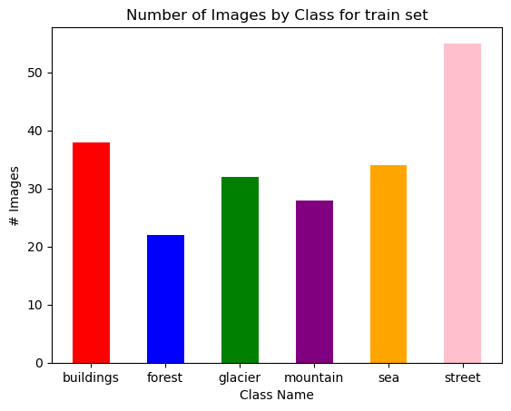

```python
colours = ['red', 'blue', 'green', 'purple', 'orange', 'pink', 'brown']
plt.bar(training_class_counts.keys(), training_class_counts.values(), width = .5, color=colours)
plt.title("Number of Images by Class for train set")
plt.xlabel('Class Name')
plt.ylabel('# Images')
```

```python
testing_classes = os.listdir('dataset/testing')

# Counting the number of images in each class
testing_class_counts = {}
for cls in testing_classes:
    testing_class_counts[cls] = len(os.listdir(f'dataset/testing/{cls}'))

testing_class_counts
```

```
{'buildings': 961,
 'forest': 1038,
 'glacier': 1033,
 'mountain': 1201,
 'sea': 1076,
 'street': 773}
```

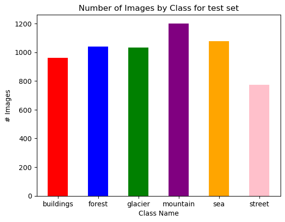

```python
plt.bar(testing_class_counts.keys(), testing_class_counts.values(), width = .5, color=colours)
plt.title("Number of Images by Class for test set")
plt.xlabel('Class Name')
plt.ylabel('# Images')
```

```python
print(f'We have {sum(training_class_counts.values())} train images in total')
print(f'We have {sum(testing_class_counts.values())} test images in total')
print(f'We have {len(training_class_counts.values())} different classes in dataset')
```

```
We have 209 train images in total
We have 6082 test images in total
We have 6 different classes in dataset
```

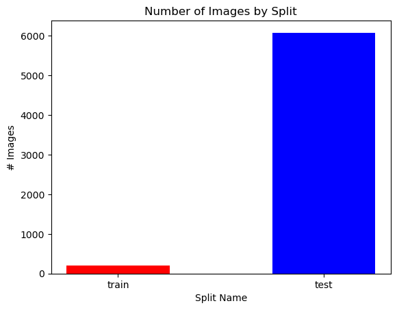

```python
plt.bar(['train','test'], [sum(training_class_counts.values()),sum(testing_class_counts.values())], width = .5, color=colours)
plt.title("Number of Images by Split")
plt.xlabel('Split Name')
plt.ylabel('# Images')
```

It seems that the training and testing dataset are flipped because we have more testing images rather than training images. Let us rename our training directory to test, and our testing directory to train.

```python
os.rename('dataset/training', 'dataset/test')
os.rename('dataset/testing', 'dataset/train')
```

```python
training_classes = os.listdir('dataset/train')

# Counting the number of images in each class
training_class_counts = {}
for cls in training_classes:
    training_class_counts[cls] = len(os.listdir(f'dataset/train/{cls}'))

training_class_counts
```

```
{'buildings': 961,
 'forest': 1038,
 'glacier': 1033,
 'mountain': 1201,
 'sea': 1076,
 'street': 773}
```

```python
for classs, freq in training_class_counts.items():
    print(f'{classs} has {freq} images in the train set')
```

```
buildings has 961 images in the train set
forest has 1038 images in the train set
glacier has 1033 images in the train set
mountain has 1201 images in the train set
sea has 1076 images in the train set
street has 773 images in the train set
```

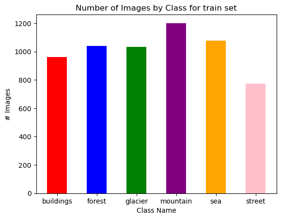

```python
colours = ['red', 'blue', 'green', 'purple', 'orange', 'pink', 'brown']
plt.bar(training_class_counts.keys(), training_class_counts.values(), width = .5, color=colours)
plt.title("Number of Images by Class for train set")
plt.xlabel('Class Name')
plt.ylabel('# Images')
```

We can observe that the distribution of the number of images for each class is fairly balanced except for the street class. The mountain class has the most images and the street class has the least images in the train set.

```python
testing_classes = os.listdir('dataset/test')

# Counting the number of images in each class
testing_class_counts = {}
for cls in testing_classes:
    testing_class_counts[cls] = len(os.listdir(f'dataset/test/{cls}'))

testing_class_counts
```

```
{'buildings': 38,
 'forest': 22,
 'glacier': 32,
 'mountain': 28,
 'sea': 34,
 'street': 55}
```

```python
for classs, freq in testing_class_counts.items():
    print(f'{classs} has {freq} images in the test set')
```

```
buildings has 38 images in the test set
forest has 22 images in the test set
glacier has 32 images in the test set
mountain has 28 images in the test set
sea has 34 images in the test set
street has 55 images in the test set
```

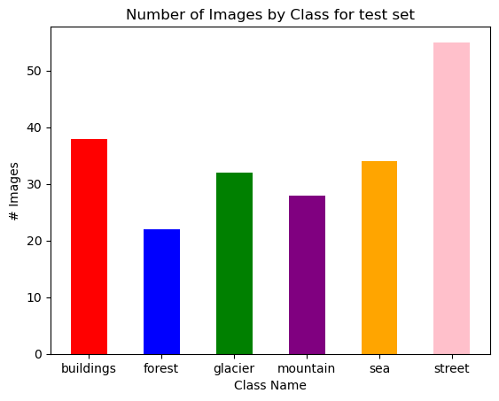

```python
plt.bar(testing_class_counts.keys(), testing_class_counts.values(), width = .5, color=colours)
plt.title("Number of Images by Class for test set")
plt.xlabel('Class Name')
plt.ylabel('# Images')
```

For our test set, we can see that the distribution of the number of images for each class is fairly balanced except for the street class. This time the street class has the most images and the forest class has the least images in the test set.

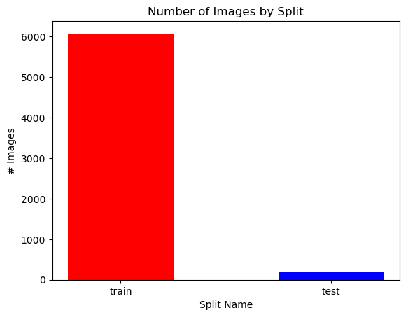

```python
plt.bar(['train','test'], [sum(training_class_counts.values()),sum(testing_class_counts.values())], width = .5, color=colours)
plt.title("Number of Images by Split")
plt.xlabel('Split Name')
plt.ylabel('# Images')
```

This is the correct split, we now have more train images compared to test images.

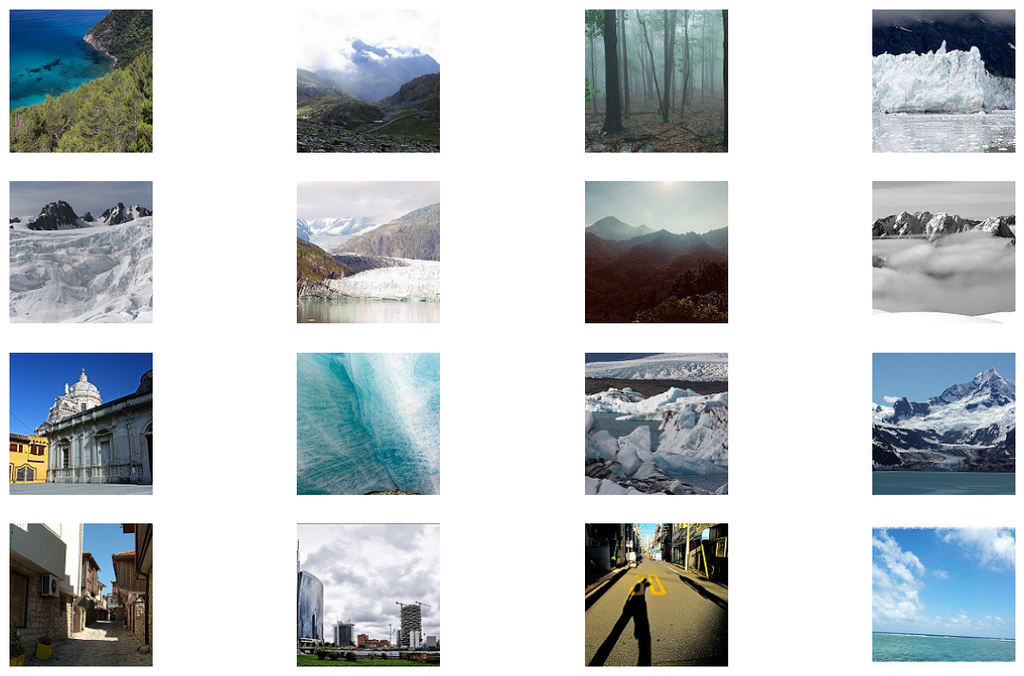

```python
# randomly view train images
train_folder = 'dataset/train'
images = []
for folder in os.listdir(train_folder):
  for image in os.listdir(train_folder + '/' + folder):
    images.append(os.path.join(train_folder, folder, image))

plt.figure(1, figsize=(15, 9))
plt.axis('off')
n = 0
for i in range(16):
  n += 1
  random_img = random.choice(images)
  imgs = plt.imread(random_img)
  plt.subplot(4, 4, n)
  plt.axis('off')
  plt.imshow(imgs)

plt.show()
```

```python
files = {}
for i in os.listdir('dataset/train'):
    files[i] = []
    for j in os.listdir(f'dataset/train/{i}'):
        files[i].append(os.path.join('dataset/train', i, j))
images = files
for i in os.listdir('dataset/train'):
    images[i] = [cv2.imread(i) for i in images[i]]
```

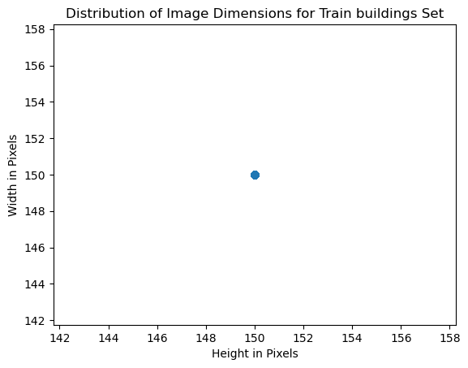

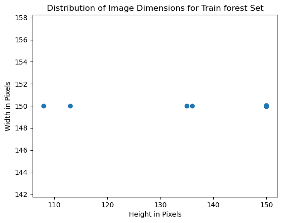

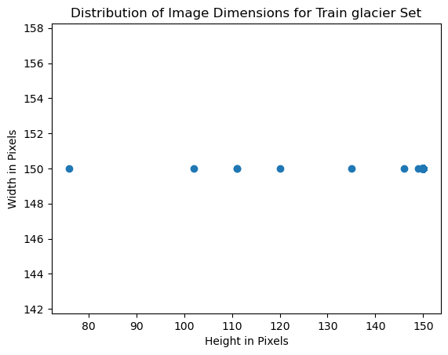

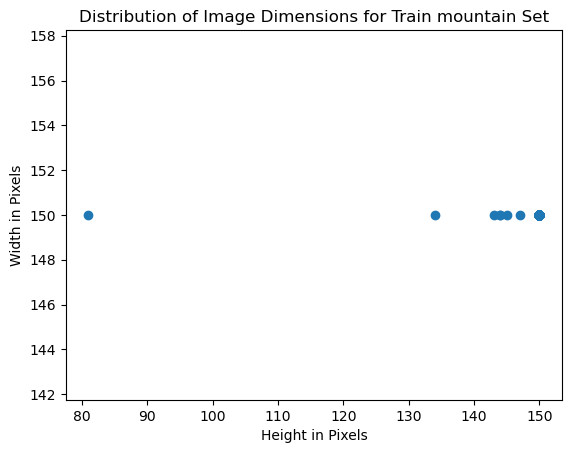

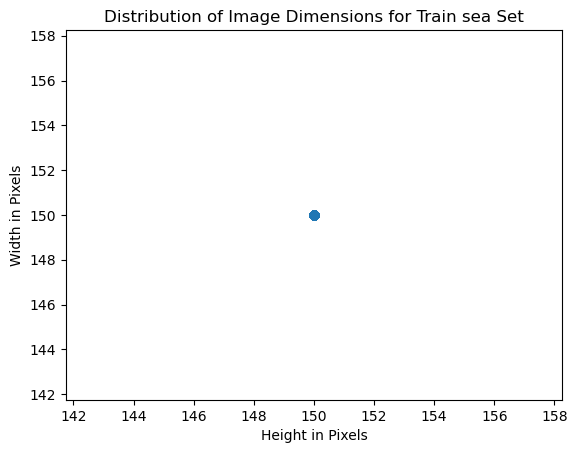

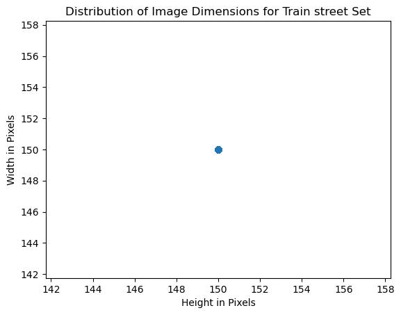

```python
for i in os.listdir('dataset/train'):
    heights = [j.shape[0] for j in images[i]]
    widths = [j.shape[1] for j in images[i]]
    plt.scatter(heights, widths)
    plt.xlabel("Height in Pixels")
    plt.ylabel("Width in Pixels")
    plt.title(f"Distribution of Image Dimensions for Train {i} Set")
    plt.show()
```

After observing the images dimensions for all the classes in the train set, we can see that all images has a width of 150 pixels. Only their heights vary. For the buildings, sea, and street classes, their width and height are the same dimmensions, which is 150x150 pixels.

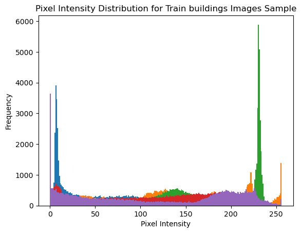

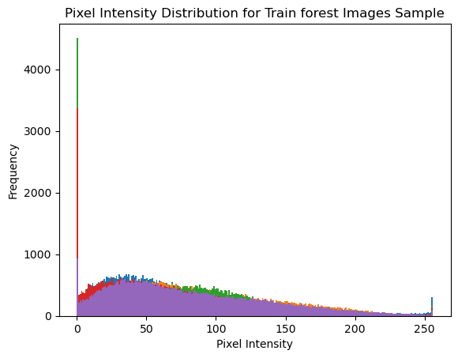

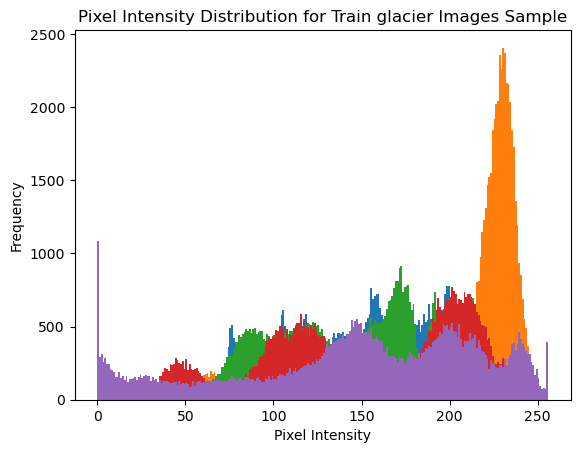

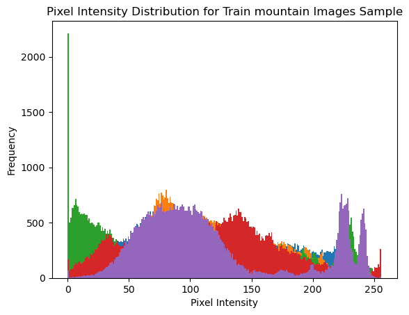

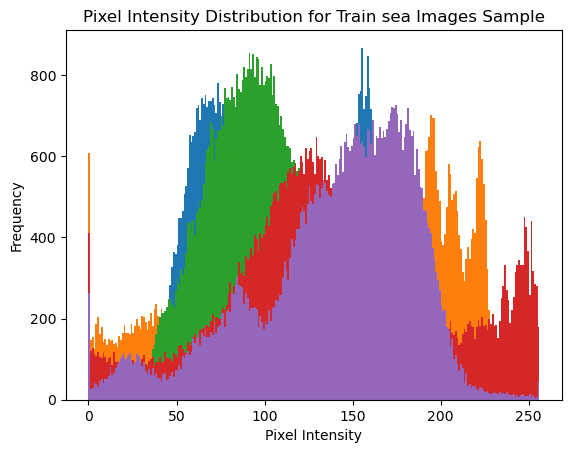

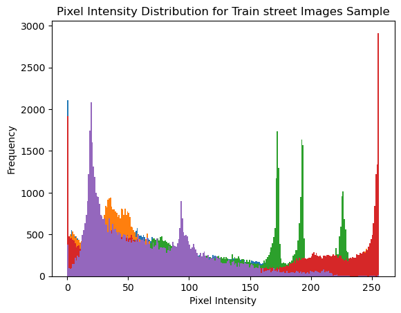

```python
for i in images.keys():
    sample_images = random.sample(images[i], 5)
    for img in sample_images:
        plt.hist(img.ravel(), 256, [0, 256])
    plt.xlabel('Pixel Intensity')
    plt.ylabel('Frequency')
    plt.title(f'Pixel Intensity Distribution for Train {i} Images Sample')
    plt.show()
```

When viewing the pixel intensity generally, the closer the pixel intensity is to 0, the darker it is. In contrast, the closer the pixel intensity is to 255 the brighter the pixel is. We can observe that the buildings' and mountains' pixel densities are distributed fairly evenly. The forests' pixel density is more towards 0 meaning they are darker images. In contrast, the glaciers' pixel density is more towards 255 meaning they are brighter images. Sea images are more in the middle meaning that they are distributed normally and produced in between dark and bright images. In contrast, street images are more towards the extreme ends, they are both bright and dark because they are distributed closer to 0 and 255.

```python
files = {}
for i in os.listdir('dataset/test'):
    files[i] = []
    for j in os.listdir(f'dataset/test/{i}'):
        files[i].append(os.path.join('dataset/test', i, j))
images = files
for i in os.listdir('dataset/test'):
    images[i] = [cv2.imread(i) for i in images[i]]
```

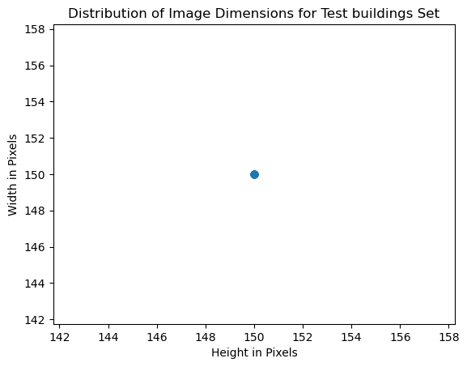

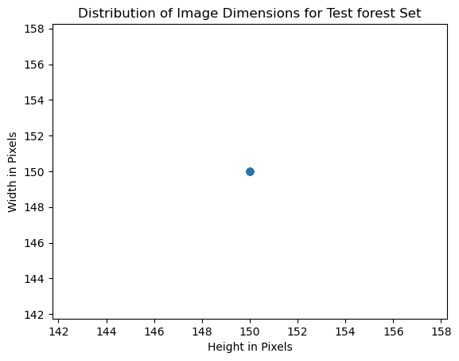

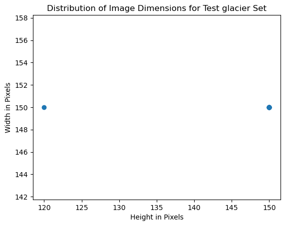

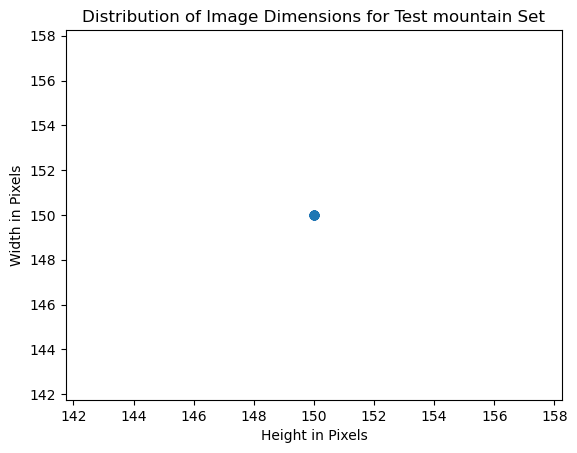

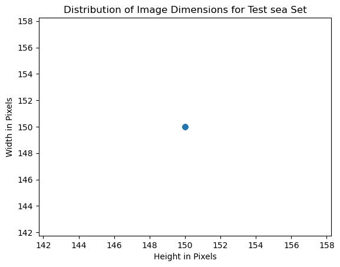

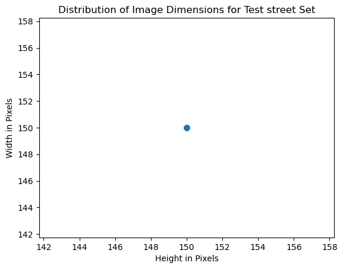

```python
for i in os.listdir('dataset/test'):
    heights = [j.shape[0] for j in images[i]]
    widths = [j.shape[1] for j in images[i]]
    plt.scatter(heights, widths)
    plt.xlabel("Height in Pixels")
    plt.ylabel("Width in Pixels")
    plt.title(f"Distribution of Image Dimensions for Test {i} Set")
    plt.show()
```

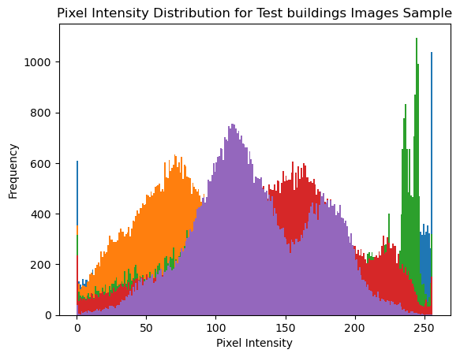

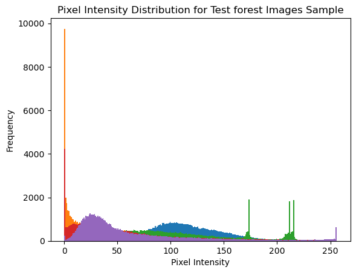

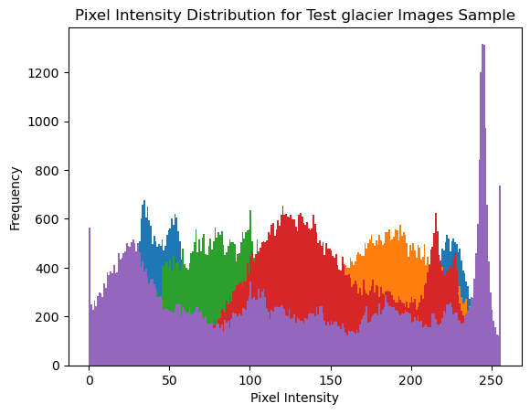

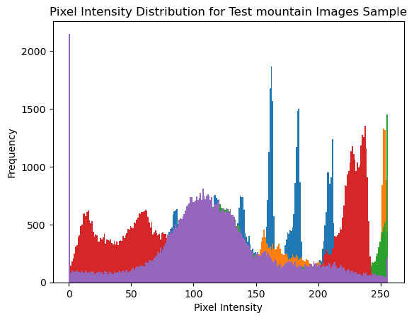

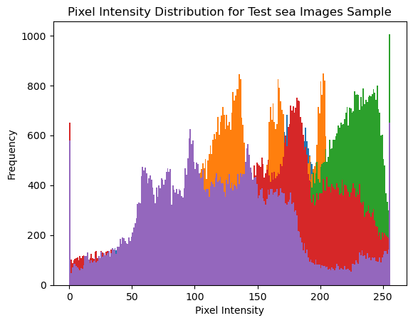

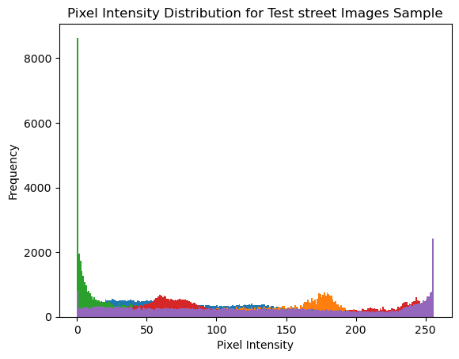

```python
for i in images.keys():
    sample_images = random.sample(images[i], 5)
    for img in sample_images:
        plt.hist(img.ravel(), 256, [0, 256])
    plt.xlabel('Pixel Intensity')
    plt.ylabel('Frequency')
    plt.title(f'Pixel Intensity Distribution for Test {i} Images Sample')
    plt.show()
```

```python
# Read input images and assign labels based on folder names
print(os.listdir("dataset/"))

SIZE = 150  #Resize images

#Capture training data and labels into respective lists
train_images = []
train_labels = []

for directory_path in glob.glob("dataset/train/*"):
    label = directory_path.split("\\")[-1]
    print(label)
    for img_path in glob.glob(os.path.join(directory_path, "*.jpg")):
        img = cv2.imread(img_path, cv2.IMREAD_COLOR)
        img = cv2.resize(img, (SIZE, SIZE))
        img = cv2.cvtColor(img, cv2.COLOR_RGB2BGR)
        train_images.append(img)
        train_labels.append(label)

#Convert lists to arrays
train_images = np.array(train_images)
train_labels = np.array(train_labels)


# Capture test/validation data and labels into respective lists

test_images = []
test_labels = []
for directory_path in glob.glob("dataset/test/*"):
    fruit_label = directory_path.split("\\")[-1]
    for img_path in glob.glob(os.path.join(directory_path, "*.jpg")):
        img = cv2.imread(img_path, cv2.IMREAD_COLOR)
        img = cv2.resize(img, (SIZE, SIZE))
        img = cv2.cvtColor(img, cv2.COLOR_RGB2BGR)
        test_images.append(img)
        test_labels.append(fruit_label)

#Convert lists to arrays
test_images = np.array(test_images)
test_labels = np.array(test_labels)

#Encode labels from text to integers.
from sklearn import preprocessing
le = preprocessing.LabelEncoder()
le.fit(test_labels)
test_labels_encoded = le.transform(test_labels)
le.fit(train_labels)
train_labels_encoded = le.transform(train_labels)

#Split data into test and train datasets (already split but assigning to meaningful convention)
x_train, y_train, x_test, y_test = train_images, train_labels_encoded, test_images, test_labels_encoded

# Normalize pixel values to between 0 and 1
x_train, x_test = x_train / 255.0, x_test / 255.0
```

```
['test', 'train']
dataset/train/buildings
dataset/train/forest
dataset/train/glacier
dataset/train/mountain
dataset/train/sea
dataset/train/street
```

# 2. Build the suitable Image classification model using pretrained InceptionV3 for feature extraction and either Random Forest or XGBoost for classification.

```python
Inception_V3 = InceptionV3(
    include_top=False,
    weights="imagenet",
    input_shape=(150, 150, 3)
)
Inception_V3.trainable = False
```

[output not shown]

```python
Inception_V3.summary()
```

```
Model: "inception_v3"
__________________________________________________________________________________________________
 Layer (type)                Output Shape                 Param #   Connected to
==================================================================================================
 input_1 (InputLayer)        [(None, 150, 150, 3)]        0         []

 conv2d (Conv2D)             (None, 74, 74, 32)           864       ['input_1[0][0]']

 batch_normalization (Batch  (None, 74, 74, 32)           96        ['conv2d[0][0]']
 Normalization)

 activation (Activation)     (None, 74, 74, 32)           0         ['batch_normalization[0][0]']

 conv2d_1 (Conv2D)           (None, 72, 72, 32)           9216      ['activation[0][0]']

 batch_normalization_1 (Bat  (None, 72, 72, 32)           96        ['conv2d_1[0][0]']
 chNormalization)

 activation_1 (Activation)   (None, 72, 72, 32)           0         ['batch_normalization_1[0][0]'
                                                                    ]

 conv2d_2 (Conv2D)           (None, 72, 72, 64)           18432     ['activation_1[0][0]']

 batch_normalization_2 (Bat  (None, 72, 72, 64)           192       ['conv2d_2[0][0]']
 chNormalization)

 activation_2 (Activation)   (None, 72, 72, 64)           0         ['batch_normalization_2[0][0]'
                                                                    ]

 max_pooling2d (MaxPooling2  (None, 35, 35, 64)           0         ['activation_2[0][0]']
 D)

 conv2d_3 (Conv2D)           (None, 35, 35, 80)           5120      ['max_pooling2d[0][0]']

 batch_normalization_3 (Bat  (None, 35, 35, 80)           240       ['conv2d_3[0][0]']
 chNormalization)

 activation_3 (Activation)   (None, 35, 35, 80)           0         ['batch_normalization_3[0][0]'
                                                                    ]

```

[output cut: 811 more lines]

```
 )                                                                   'activation_92[0][0]']

 activation_93 (Activation)  (None, 3, 3, 192)            0         ['batch_normalization_93[0][0]
                                                                    ']

 mixed10 (Concatenate)       (None, 3, 3, 2048)           0         ['activation_85[0][0]',
                                                                     'mixed9_1[0][0]',
                                                                     'concatenate_1[0][0]',
                                                                     'activation_93[0][0]']

==================================================================================================
Total params: 21802784 (83.17 MB)
Trainable params: 0 (0.00 Byte)
Non-trainable params: 21802784 (83.17 MB)
__________________________________________________________________________________________________
```

```python
feature_extractor = Inception_V3.predict(x_train)
```

```
2023-10-18 21:41:53.444714: I tensorflow/compiler/xla/stream_executor/cuda/cuda_dnn.cc:442] Loaded cuDNN version 8700
```

```python
features = feature_extractor.reshape(feature_extractor.shape[0], -1)
X_for_training = features
```